# RQ1

Nadiia Honcharenko

# Final Analysis

**1. Are customers willing to travel long distances to purchase products?**

**Algorithms selected:** SVM, K-nearest neighbor, Random Forest

**Reason for Algorithm Selections:** According to the several papers and studies, in the event that the relationship between two variables is non-linear and we are handling a two class classification problem, nothing is going to be nearly as accurate as SVM. Concerning K-nearest neighbor algorithm, it runs generally slower and has lower accuracy in comparision with SVM, but it’s got some nice practical qualities. It’s easy to train, because k-NN is ranked as a lazy algorithmus and in fact there’s no training at all. Consequently it’s easy to use, and it’s easy to understand the results. However k-NN classification is used more in the industry than an academic might think. In comparision with k-NN classification, Random Forest is a great algorithm to train early in the model development process, to see how it performs. Considering the context of difference between Forest and Vectors algorithms it should be mentioned, that with Random Forest data can be used, roughly speaking, as they are, when SVM maximizes the “margin” and thus relies on the concept of “distance” between different points. This tree-algorithm is also very hard to beat in terms of performance. Moreover, in contrast with SVM and KNN Random Forest doesn’t demand a parameter tuning to reach a high accuracy.

**Analysis** **1) Data preparation for classification**

```r
library(caret)
library(randomForest)
library(e1071)
library(ggplot2)
library(dplyr)
library(tidyverse)

# Creating of useful functions
create_conf_matrix <- function(refLabels, predictLabels, positiveLabel){
  conf_matrix <- confusionMatrix(
    refLabels, # reference labels
    predictLabels, # predicted labels
    positive = positiveLabel, # label that corresponds to a "positive" results (optional)
    dnn = c("actual", "predicted") # names of the confusion matrix dimensions  (optional)
  )
  return (conf_matrix)
}

get_evaluation <- function(refLabels, predictLabels, positiveLabel){
  conf_matrix <- create_conf_matrix(refLabels, predictLabels, positiveLabel)
  conf_matrix
  print(conf_matrix$overall["Accuracy"])
  print(conf_matrix$byClass["Sensitivity"])
  print(conf_matrix$byClass["Specificity"])
}

# Data preparation
cleared_supermarket_data <- read_csv("D:/Data-Science-with-R/Data-Science-with-R/Input Dataset/Cleaned Dataset/Supermarket_Data_Classification.csv")
cleared_supermarked_tbl <- tbl_df(cleared_supermarket_data)

cleared_supermarked_tbl$class <- as.factor(cleared_supermarked_tbl$class)
```

**2) Stratified k-fold cross validation**

```r
flds <- createFolds(factor(cleared_supermarked_tbl$class), k = 5, list = FALSE, returnTrain = TRUE)

comb_factor <- tbl_df(cbind(cleared_supermarked_tbl, flds))
train_folders <- c(1,3,4)
test_folders <- c(2,5)
train_data <- cleared_supermarked_tbl[comb_factor$flds %in% train_folders,]
test_data <- cleared_supermarked_tbl[comb_factor$flds %in% test_folders,]

# splitting data to test and training
train_ds <- train_data[, -26]
y_train <- train_data %>%
  pull(class)
y_test <- test_data %>%
  pull(class)
test_ds <- test_data[, -26]
```

**3) Functions for classifying and plotting**

```r
classify_with_fit <- function(fit, title){
  train_predicted <- predict(fit, train_ds, type = "class")
  print("Evaluation for the training")
  get_evaluation(y_train, train_predicted, "Yes")
  predicted <- predict(fit, test_ds, type = "class")
  print("Evaluation for the tests")
  get_evaluation(y_test, predicted, "Yes")
  draw_plot_for_classes(test_ds, predicted, title)
}

draw_plot_for_classes <- function(data, predicted, title){
  plot_data <- cbind(data, predicted)
  ggplot(plot_data, aes(x = predicted, fill = predicted)) +
    geom_bar() +
    xlab("Prediction") + ylab("Customer count") +
    theme_bw() +
    theme(legend.title = element_blank()) +
    ggtitle(title)
}
```

## Classification

**4) Classification with SVM**

```r
#tune SVM
tuneSvm <- tune(svm, class ~ ., data = train_data, ranges = list(gamma = 2^(-1:1)),
     cost = 2^(2:4), tunecontrol = tune.control(sampling = "fix"))
summary(tuneSvm)
```

```
##
## Parameter tuning of 'svm':
##
## - sampling method: fixed training/validation set
##
## - best parameters:
##  gamma
##    0.5
##
## - best performance: 0.05466744
##
## - Detailed performance results:
##   gamma      error dispersion
## 1   0.5 0.05466744         NA
## 2   1.0 0.06709186         NA
## 3   2.0 0.09442558         NA
```

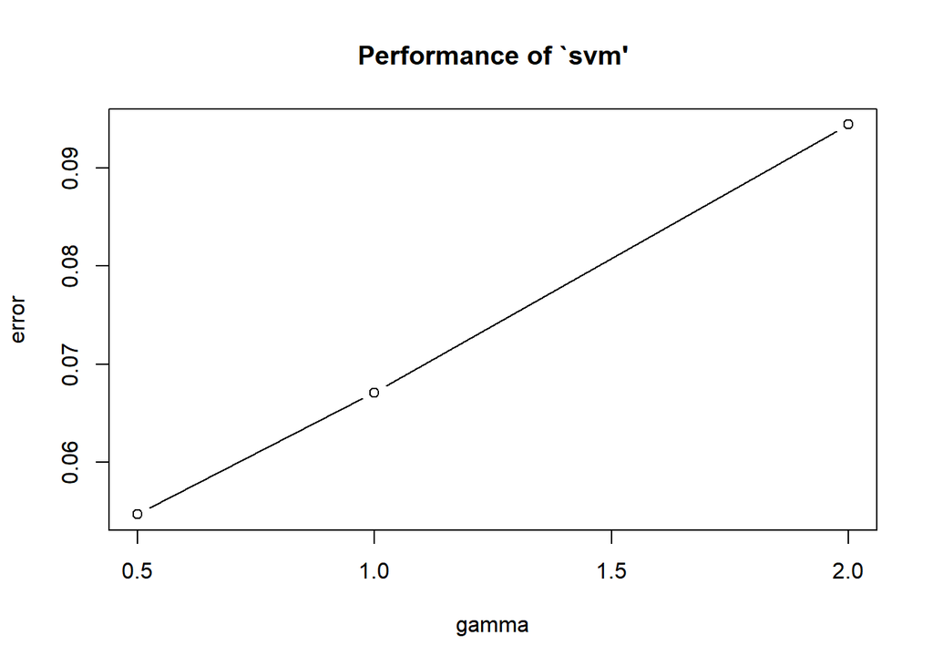

```r
plot(tuneSvm)
```

```
## [1] "Evaluation for the training"
##  Accuracy
## 0.9755094
## Sensitivity
##   0.9776803
## Specificity
##   0.9701607
## [1] "Evaluation for the tests"
##  Accuracy
## 0.9488549
## Sensitivity
##   0.9524192
## Specificity
##   0.9396193
```

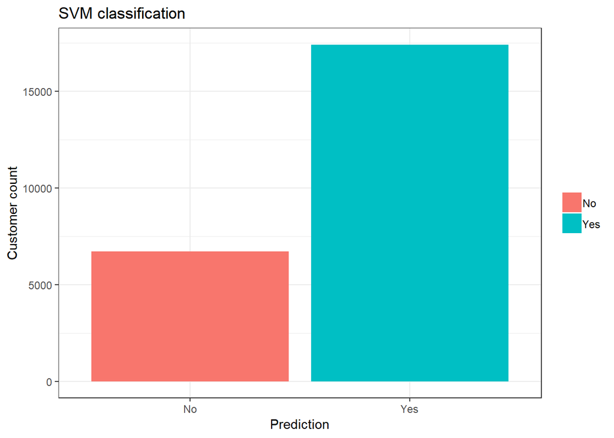

```r
#classify with best params
svmFit <- svm(class ~ ., data = train_data, kernel = "radial",
           cost = 1, gamma = 0.5,
           scale=TRUE, cachesize=95)

#plot(svmFit, train_data)
classify_with_fit(svmFit, "SVM classification")
```

**5) Classification with K-nearest neighbor**

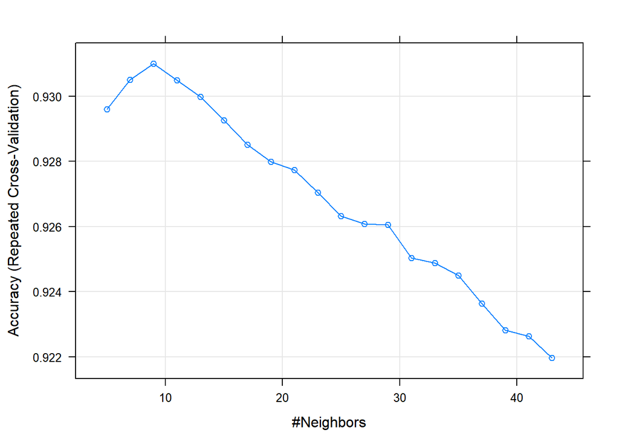

```r
# train knn classifier

set.seed(400)
ctrl <- trainControl(method="repeatedcv",repeats = 3)
knnTrain <- train(class ~ ., data = train_data, method = "knn",
                trControl = ctrl, preProcess = c("center","scale"), tuneLength = 20)
plot(knnTrain)
```

```r
#classify with best params
knnFit <- knn3(train_ds, y_train, k = 7)
classify_with_fit(knnFit, "KNN classification")
```

```
## [1] "Evaluation for the training"
##  Accuracy
## 0.9541664
## Sensitivity
##   0.9609777
## Specificity
##   0.9371682
## [1] "Evaluation for the tests"
##  Accuracy
## 0.9353957
## Sensitivity
##   0.9504084
## Specificity
##   0.8986728
```

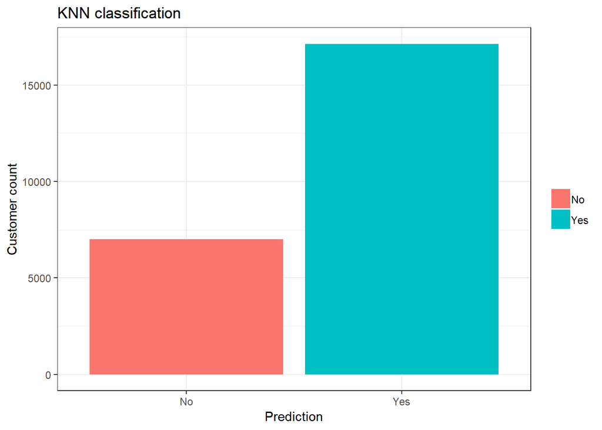

**6) Classification with Random Forest**

```r
randomFit <- randomForest(class ~ ., train_data, ntree=500)
classify_with_fit(randomFit, "Random Forest")
```

```
## [1] "Evaluation for the training"
## Accuracy
##        1
## Sensitivity
##           1
## Specificity
##           1
## [1] "Evaluation for the tests"
##  Accuracy
## 0.9803702
## Sensitivity
##   0.9833294
## Specificity
##   0.9731953
```

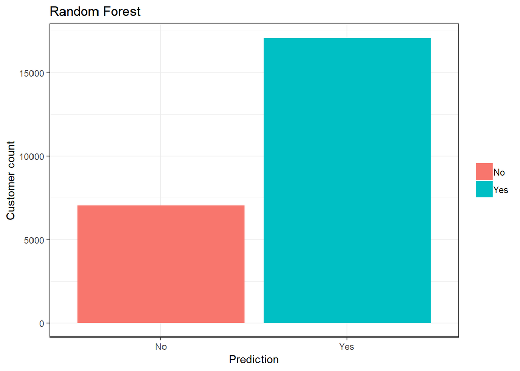

**Observations:** Binary classification gives an opportunity to divide the data into two separate classes, which will help to understand whether the buyer will go a long distance to the store, based on certain factors, or not. Thus, it is possible to observe an importance of the shop location criteria for customers in comparision with such measures as prices, product uniqueness, range of choice, etc.

**Applications:** These insights obtained can be further utilized by the business to create the best selling politics and strategy in context of the stores location, which will increase its revenue.